# FIFA 2019 - Multinomial Logistic Regression for Player Position

Sau Kha

8/26/2020

# Part II Introduction

Part I of the study concludes that randomForest for classification for players’ International Reputation based on players’ skill ratings on the FIFA 2019 data performed poorly due to extremely skewed distribution of players’ rank. For similar reasons, the classification model to predict players’ positions based on skill ratings did not perform well either.

However, randomForest for regression is a pretty good tool for the same data set in analyzing players’ skill ratings to predict their Overall Ratings. Predicted Overall Ratings strongly correlate with the values in the test set. Further, using the tuneRF function, the ntree and mtry parameters can be set to a lower number, thus reducing the size of the “forest” but keeping up the performance as measured by the mean of squared residuals and percent variance explained.

The following section documents an attempt to use Multinomial Logistic Regression to predict a player’s position based on skill ratings.

# D) Multinomial Logistic Regression

Multinom function from the nnet package may be used to estimate a multinomial logistic regression model. The multinom function does not require the data to be reshaped (as the mlogit package does). (https://stats.idre.ucla.edu/r/dae/multinomial-logistic-regression/) Multinomial logistic regression does not assume normality, linearity, or homoscedasticity.

## Load library

```r
# load library
library(utils)
library(stats)
library(tidyverse)
library(caTools)
library(dplyr)
library(caret)
library(foreign)
library(nnet)
library(ggplot2)
library(reshape2)
library(MASS)
library(broom)
```

## Data Preparation

A new column NewPosition is created to group players into one of the following categories: Offense, Midfield and Defense based on their actual position recorded in the Position column. This new grouping results in three multinomial classes. Players in the same position category play in similar roles and in similar region of the game field. They are expected to master similar skills required for the positions. For example, players who rate high in attacking skills such as crossing, finishing, heading accuracy, short passing and volleys, are likely placed as offense and play in the front of the game field.

Players are placed in their NewPosition Category, Offense, Defense and Midfield, according to their actual positions. See details below:

**Offense**: Position codes ends with “S”, “T”, “W” or “F”  
*Striker* “LS” “ST” “RS”  
- “LS” Left Striker  
- “ST” Striker  
- “RS” Right Striker  
*Wing*: “LW” “RW”  
- “LW” Left Wing  
- “RW” Right Wing  
*Forward*: “LF” “CF” “RF”  
- “LF” Left Forward  
- “CF” Centre Forward  
- “RF” Right Forward

**Midfield**: Position code ends with “M”  
*Attacking Mid Field*: “LAM” “CAM” “RAM”  
- “LAM” Left Attacking Mid Field  
- “CAM” Center Attacking Mid Field  
- “RAM” Right Attacking Mid Field  
*Center Mid Field*: “LCM” “CM” “RCM”  
- “LCM” Left Center Mid Field  
- “CM” Center Mid Field  
- “RCM” Right Center Mid Field  
*Mid Field*: “LM” “RM”  
- “LM” Left Midfield  
- “RM” Right Midfield  
*Defensive Mid Field*: “LDM” “CDM” “RDM”  
- “LDM” Left Defensive Mid Field  
- “CDM” Centre Defensive Mid Field  
- “RDM” Right Defensive Mid Field

**Defense**: Position code ends with “B”  
*Centre Back*: “LCB” “CB” “RCB”  
- “LCB” Left Centre Back  
- “RCB” Right Centre Back  
- “CB” Centre Back  
*Full Back*: “LB” “RB”  
- “LB” Left Full Back  
- “RB” Right Full Back  
*Wing Back*: “LWB” “RWB”  
- “LWB” Left Wing Back  
- “RWB” Right Wing Back

### Read, Prepare and Split Data

```r
# read and prep data
df2 <- read.csv(file = 'data.csv', dec = "+")
# remove data with missing entries in rating for various positions
# all observations for goalkeepers are also removed for same missing entries.
df2 <- na.omit(df2)

# create logic vectors to put to group Positions into 3 categories:
# logic vector for Offense: position code ends with S, T, W or F
offense <- grepl("^.+(S|T|W|F)$", df2$Position)
# logic vector for Defense: position code ends B
defense <- grepl("^.+(B)$", df2$Position)
# logic vector for Midfield: position code ends M
midfield <- grepl("^.+(M)$", df2$Position)
# Goalkeepers are removed from data set
# position code = GK,
nrow(df2[df2$Position == "GK", ])
```

```
## [1] 0
```

```r
# create and populate NewPosition col
df2$NewPosition[offense] <- 'Offense'
df2$NewPosition[midfield] <- 'Midfield'
df2$NewPosition[defense] <- 'Defense'
# convert col to factor
df2$NewPosition <- as.factor(df2$NewPosition)

# Visualize new grouping
table(df2$NewPosition)
```

```
##
##  Defense Midfield  Offense
##     5866     6838     3418
```

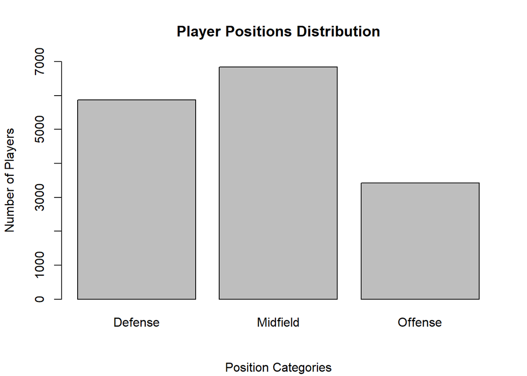

```r
plot(df2$NewPosition, main = "Player Positions Distribution", ylim = c(0, 7000),
     sub = "Position Categories", ylab = "Number of Players")
```

```r
# extract dependent and independent variables
# col 90 = NewPosition, col 55:88 = skills ratings
df2s <- df2[, c(90, 55:88)]
head(df2s)  # take a peek at first 6 rows of data
```

```
##   NewPosition Crossing Finishing HeadingAccuracy ShortPassing Volleys Dribbling
## 1     Offense       84        95              70           90      86        97
## 2     Offense       84        94              89           81      87        88
## 3     Offense       79        87              62           84      84        96
## 5    Midfield       93        82              55           92      82        86
## 6     Offense       81        84              61           89      80        95
## 7    Midfield       86        72              55           93      76        90
##   Curve FKAccuracy LongPassing BallControl Acceleration SprintSpeed Agility
## 1    93         94          87          96           91          86      91
## 2    81         76          77          94           89          91      87
## 3    88         87          78          95           94          90      96
## 5    85         83          91          91           78          76      79
## 6    83         79          83          94           94          88      95
## 7    85         78          88          93           80          72      93
##   Reactions Balance ShotPower Jumping Stamina Strength LongShots Aggression
```

[output cut: 20 more lines]

```r
# split data into train and test
# Set Seed so that same sample can be reproduced
set.seed(101)
# split sample while keeping
spl = sample.split(df2s$NewPosition, SplitRatio = 0.8)
df2s_train = subset(df2s, spl == TRUE)
df2s_test  = subset(df2s, spl == FALSE)
rm(spl)
```

# Initial Model - multinom function Using All Variables

```r
# choose NewPosition col as the baseline for relevel function
# reference the level
# new col NewPosition2 created
df2s_train$NewPosition2 <- relevel(df2s_train$NewPosition, ref = "Defense")

# create the initial multinomial regression model
mn1 <- multinom(NewPosition2 ~ . - NewPosition, data = df2s_train) # - NewPostion in formula
```

## Initial Model Metrics

From the block of coefficients, the first row compares Midfield to Defense baseline, which was specified in the ref argument of the relevel function. The second row compares Offense to Defense baseline. The log-likelihood of placing a player in Midfield to Defense baseline may be calculated from the intercept and coefficients from the first row. Similar calculation is done for the log-likelihood of classifying a player in Offense to Defense.

```r
# summary of mn1 model
summary(mn1)
```

```
## Call:
## multinom(formula = NewPosition2 ~ . - NewPosition, data = df2s_train)
##
## Coefficients:
##          (Intercept)   Crossing  Finishing HeadingAccuracy ShortPassing
## Midfield  -0.2038460 -0.1012958 0.03111832     -0.05306698    0.1541389
## Offense   -0.7091105 -0.1362239 0.12755069     -0.03315961    0.1203483
##              Volleys  Dribbling       Curve    FKAccuracy LongPassing
## Midfield 0.001291189 0.02739678 -0.03577148  0.0003293757 0.070842604
## Offense  0.015715025 0.01549612 -0.02842632 -0.0084508052 0.006242604
##          BallControl Acceleration SprintSpeed     Agility     Reactions
## Midfield  0.03791966  -0.01116638 -0.04185465 0.004707306  0.0043532973
## Offense   0.04931149  -0.01610851 -0.03490223 0.004340077 -0.0002016946
##             Balance  ShotPower     Jumping    Stamina     Strength  LongShots
## Midfield 0.02170228 0.02073994 -0.01777400 0.02527767 -0.014351913 0.02342943
## Offense  0.01594053 0.03105583 -0.01823153 0.01897319 -0.004439411 0.01802959
##          Aggression Interceptions Positioning     Vision  Penalties   Composure
## Midfield 0.03516077   -0.03299572 0.009385911 0.08818237 0.01365194 -0.03143747
## Offense  0.04238887   -0.04360509 0.056250779 0.05555605 0.02363180 -0.01305778
##              Marking StandingTackle SlidingTackle   GKDiving  GKHandling
## Midfield -0.06121864    -0.06887394   -0.09773438 0.01825415 0.009844651
## Offense  -0.09408543    -0.08882476   -0.10040245 0.01481882 0.014943307
##            GKKicking GKPositioning    GKReflexes
## Midfield -0.02329566    0.01366312 -0.0004472832
## Offense  -0.02719048   -0.01995371 -0.0222091180
##
## Std. Errors:
##          (Intercept)    Crossing   Finishing HeadingAccuracy ShortPassing
## Midfield   0.3193072 0.005843747 0.005732851     0.006495564   0.01331151
## Offense    0.2195315 0.008168541 0.010564814     0.008153775   0.01713584
##              Volleys   Dribbling       Curve  FKAccuracy LongPassing
## Midfield 0.005263316 0.008861524 0.005516550 0.004954327 0.009621782
## Offense  0.007865383 0.014711264 0.007903453 0.006688986 0.011867880
##          BallControl Acceleration SprintSpeed     Agility   Reactions
## Midfield  0.01230673  0.008513405 0.007730581 0.006630029 0.009937436
## Offense   0.01814030  0.011935791 0.011014739 0.009099151 0.012585962
##              Balance   ShotPower     Jumping     Stamina    Strength
## Midfield 0.005705857 0.006093779 0.004499058 0.004993141 0.005648163
## Offense  0.007409507 0.009639382 0.005759705 0.006620908 0.006906806
##            LongShots  Aggression Interceptions Positioning      Vision
## Midfield 0.005852781 0.005366640   0.009085275 0.005831026 0.007144724
## Offense  0.008980125 0.006415776   0.010140453 0.010707418 0.010523303
##            Penalties   Composure     Marking StandingTackle SlidingTackle
## Midfield 0.005211578 0.007359287 0.007835920     0.01435268    0.01225774
## Offense  0.007391450 0.010247949 0.008593287     0.01588851    0.01395280
##            GKDiving GKHandling  GKKicking GKPositioning GKReflexes
## Midfield 0.01327582 0.01351619 0.01312327    0.01331072 0.01348492
## Offense  0.01775543 0.01805899 0.01751739    0.01797896 0.01799563
##
## Residual Deviance: 8524.135
## AIC: 8664.135
```

```r
# z-test: calculate and print z
z1 <- summary(mn1)$coefficients/summary(mn1)$standard.errors
z1
```

```
##          (Intercept)  Crossing Finishing HeadingAccuracy ShortPassing   Volleys
## Midfield  -0.6384009 -17.33405   5.42807       -8.169725    11.579369 0.2453185
## Offense   -3.2301088 -16.67665  12.07316       -4.066780     7.023194 1.9979988
##          Dribbling     Curve  FKAccuracy LongPassing BallControl Acceleration
## Midfield  3.091656 -6.484394  0.06648243   7.3627319    3.081213    -1.311623
## Offense   1.053351 -3.596696 -1.26339098   0.5260083    2.718340    -1.349597
##          SprintSpeed   Agility   Reactions  Balance ShotPower   Jumping
## Midfield   -5.414166 0.7099977  0.43807047 3.803509  3.403462 -3.950604
## Offense    -3.168684 0.4769760 -0.01602537 2.151361  3.221765 -3.165358
##           Stamina   Strength LongShots Aggression Interceptions Positioning
## Midfield 5.062479 -2.5409880  4.003128   6.551729     -3.631780     1.60965
## Offense  2.865648 -0.6427589  2.007722   6.606975     -4.300113     5.25344
##             Vision Penalties Composure    Marking StandingTackle SlidingTackle
## Midfield 12.342307  2.619539 -4.271809  -7.812566      -4.798682     -7.973276
## Offense   5.279335  3.197180 -1.274185 -10.948712      -5.590504     -7.195862
##           GKDiving GKHandling GKKicking GKPositioning  GKReflexes
## Midfield 1.3749917   0.728360 -1.775141      1.026475 -0.03316913
## Offense  0.8346076   0.827472 -1.552200     -1.109837 -1.23413982
```

```r
# calculate p value for 2-tailed z test
p1 <- (1 - pnorm(abs(z1), 0, 1)) * 2
p1
```

```
##          (Intercept) Crossing   Finishing HeadingAccuracy ShortPassing
## Midfield 0.523212775        0 5.69667e-08    2.220446e-16 0.000000e+00
## Offense  0.001237431        0 0.00000e+00    4.766711e-05 2.168488e-12
##             Volleys   Dribbling        Curve FKAccuracy  LongPassing
## Midfield 0.80620979 0.001990435 8.908940e-11  0.9469937 1.800782e-13
## Offense  0.04571679 0.292180327 3.222846e-04  0.2064487 5.988824e-01
##          BallControl Acceleration  SprintSpeed   Agility Reactions      Balance
## Midfield  0.00206159    0.1896474 6.157507e-08 0.4777056 0.6613352 0.0001426606
## Offense   0.00656104    0.1771451 1.531307e-03 0.6333792 0.9872142 0.0314477050
##             ShotPower      Jumping      Stamina   Strength    LongShots
## Midfield 0.0006653776 7.795415e-05 4.138406e-07 0.01105397 6.251043e-05
## Offense  0.0012740338 1.548923e-03 4.161573e-03 0.52038057 4.467288e-02
##            Aggression Interceptions  Positioning       Vision   Penalties
## Midfield 5.687473e-11  2.814734e-04 1.074743e-01 0.000000e+00 0.008804859
## Offense  3.922529e-11  1.707114e-05 1.492844e-07 1.296533e-07 0.001387783
##             Composure      Marking StandingTackle SlidingTackle  GKDiving
## Midfield 1.938939e-05 5.551115e-15   1.597133e-06  1.554312e-15 0.1691340
## Offense  2.025980e-01 0.000000e+00   2.264118e-08  6.206147e-13 0.4039387
##          GKHandling  GKKicking GKPositioning GKReflexes
## Midfield  0.4663933 0.07587458     0.3046677  0.9735397
## Offense   0.4079696 0.12061448     0.2670694  0.2171508
```

```r
# confusion matrix & mis-classification error - training data
pred_train1 <- predict(mn1, df2s_train)  # predict with training data
# confusion matrix
tab_train1 <- table(pred_train1, df2s_train$NewPosition)
tab_train1
```

```
##
## pred_train1 Defense Midfield Offense
##    Defense     4318      382      16
##    Midfield     373     4681     557
##    Offense        2      407    2161
```

```r
# mis-classification
1 - sum(diag(tab_train1)/sum(tab_train1))  # diag() for diagonal matrix
```

```
## [1] 0.1346825
```

```r
# sensitivity: accuracy of predicting position correctly
tab_train1 / colSums(tab_train1)
```

```
##
## pred_train1      Defense     Midfield      Offense
##    Defense  0.9200937567 0.0813978266 0.0034093330
##    Midfield 0.0681901280 0.8557586837 0.1018281536
##    Offense  0.0007315289 0.1488661302 0.7904169715
```

## Tidy Model Metrics

Using broom package, model metrics are shown in tidy output format, which includes p value for each independent variable for each NewPosition category.

```r
tidy(mn1)
```

```
## # A tibble: 70 x 6
##    y.level  term             estimate std.error statistic  p.value
##    <chr>    <chr>               <dbl>     <dbl>     <dbl>    <dbl>
##  1 Midfield (Intercept)     -0.204      0.319     -0.638  5.23e- 1
##  2 Midfield Crossing        -0.101      0.00584  -17.3    2.60e-67
##  3 Midfield Finishing        0.0311     0.00573    5.43   5.70e- 8
##  4 Midfield HeadingAccuracy -0.0531     0.00650   -8.17   3.09e-16
##  5 Midfield ShortPassing     0.154      0.0133    11.6    5.24e-31
##  6 Midfield Volleys          0.00129    0.00526    0.245  8.06e- 1
##  7 Midfield Dribbling        0.0274     0.00886    3.09   1.99e- 3
##  8 Midfield Curve           -0.0358     0.00552   -6.48   8.91e-11
##  9 Midfield FKAccuracy       0.000329   0.00495    0.0665 9.47e- 1
## 10 Midfield LongPassing      0.0708     0.00962    7.36   1.80e-13
## # ... with 60 more rows
```

```r
glance(mn1)
```

```
## # A tibble: 1 x 4
##     edf deviance   AIC  nobs
##   <dbl>    <dbl> <dbl> <int>
## 1    70    8524. 8664. 12897
```

## Predict Using Test Data - Initial Model

```r
# predict with test data
pred_test1 <- predict(mn1, df2s_test)
```

## Evaluate Initial Predicted Results

```r
# confusion matrix
tab_test1 <- table(pred_test1, df2s_test$NewPosition)
tab_test1
```

```
##
## pred_test1 Defense Midfield Offense
##   Defense     1088       98       3
##   Midfield      84     1179     154
##   Offense        1       91     527
```

```r
# accuracy
sum(diag(tab_test1))/sum(tab_test1)
```

```
## [1] 0.8663566
```

```r
# mis-classification
1 - sum(diag(tab_test1))/sum(tab_test1)
```

```
## [1] 0.1336434
```

```r
 # sensitivity
tab_test1 / colSums(tab_test1)
```

```
##
## pred_test1     Defense    Midfield     Offense
##   Defense  0.927536232 0.083546462 0.002557545
##   Midfield 0.061403509 0.861842105 0.112573099
##   Offense  0.001461988 0.133040936 0.770467836
```

```r
# visualize
heatmap(tab_test1, mar = c(10, 5))
```

[output not shown]

# Second Model

## Manually Adjusted formula

```r
# fine-tune formula, removing variables with p > 0.05 for all other NewPostion categories
# notice that all GK skills have high p values
mn2 <- multinom(NewPosition2 ~ . - NewPosition - Volleys - FKAccuracy - Acceleration
                - Agility - Reactions - Strength - GKDiving - GKHandling - GKKicking
                - GKPositioning - GKReflexes, df2s_train)
```

## Model Metrics Summary - 2nd Model

```r
# summary of mn1 model
summary(mn2)
```

```
## Call:
## multinom(formula = NewPosition2 ~ . - NewPosition - Volleys -
##     FKAccuracy - Acceleration - Agility - Reactions - Strength -
##     GKDiving - GKHandling - GKKicking - GKPositioning - GKReflexes,
##     data = df2s_train)
##
## Coefficients:
##          (Intercept)   Crossing  Finishing HeadingAccuracy ShortPassing
## Midfield   -0.827643 -0.0996999 0.03175665     -0.05537353     0.157376
## Offense    -1.479853 -0.1357286 0.13154352     -0.03223872     0.124806
##           Dribbling       Curve LongPassing BallControl SprintSpeed    Balance
## Midfield 0.02680841 -0.03510038  0.06926406  0.03812908 -0.04793623 0.02737448
## Offense  0.01548570 -0.03040051  0.00187658  0.04767765 -0.04427070 0.01549001
##           ShotPower     Jumping    Stamina  LongShots Aggression Interceptions
## Midfield 0.01981689 -0.01822654 0.02241307 0.02363367 0.03332242   -0.03208638
## Offense  0.03631341 -0.01822687 0.01722917 0.01667922 0.04150069   -0.04325708
##          Positioning     Vision  Penalties   Composure     Marking
## Midfield 0.009146564 0.08923520 0.01390458 -0.03164196 -0.06031558
## Offense  0.056244051 0.05503362 0.02410975 -0.01081436 -0.09297067
##          StandingTackle SlidingTackle
## Midfield    -0.07224902   -0.09567189
## Offense     -0.09140624   -0.10001577
##
## Std. Errors:
##          (Intercept)    Crossing   Finishing HeadingAccuracy ShortPassing
## Midfield   0.2670041 0.005777034 0.005558181     0.006177944   0.01310414
## Offense    0.1805506 0.008045603 0.010369860     0.007724755   0.01690680
##            Dribbling       Curve LongPassing BallControl SprintSpeed
## Midfield 0.008752827 0.004975080 0.009520863  0.01218763 0.004921555
## Offense  0.014380161 0.007021469 0.011712278  0.01796280 0.006791620
##              Balance   ShotPower     Jumping     Stamina   LongShots
## Midfield 0.004849954 0.005969113 0.004401388 0.004789373 0.005708238
## Offense  0.006238814 0.009296711 0.005627208 0.006367040 0.008726344
##           Aggression Interceptions Positioning      Vision   Penalties
## Midfield 0.005200325   0.008837313 0.005755971 0.007080982 0.004967246
## Offense  0.006242798   0.009887135 0.010333693 0.010400304 0.007105413
##            Composure     Marking StandingTackle SlidingTackle
## Midfield 0.007125477 0.007729442     0.01414967    0.01214208
## Offense  0.009939876 0.008482537     0.01567482    0.01383113
##
## Residual Deviance: 8564.547
## AIC: 8660.547
```

```r
# Wald test / z-test: calculate and print z
z2 <- summary(mn2)$coefficients/summary(mn2)$standard.errors
z2
```

```
##          (Intercept)  Crossing Finishing HeadingAccuracy ShortPassing Dribbling
## Midfield   -3.099738 -17.25797  5.713497       -8.963099    12.009644  3.062829
## Offense    -8.196334 -16.86990 12.685178       -4.173430     7.381998  1.076879
##              Curve LongPassing BallControl SprintSpeed  Balance ShotPower
## Midfield -7.055240   7.2749772    3.128506   -9.740057 5.644276  3.319905
## Offense  -4.329651   0.1602233    2.654244   -6.518431 2.482845  3.906049
##            Jumping  Stamina LongShots Aggression Interceptions Positioning
## Midfield -4.141088 4.679751  4.140274   6.407758     -3.630785    1.589057
## Offense  -3.239061 2.705993  1.911364   6.647771     -4.375087    5.442783
##             Vision Penalties Composure    Marking StandingTackle SlidingTackle
## Midfield 12.602095  2.799254 -4.440679  -7.803355      -5.106057     -7.879366
## Offense   5.291539  3.393152 -1.087977 -10.960243      -5.831407     -7.231206
```

```r
# calculate p value for 2-tailed z test
p2 <- (1 - pnorm(abs(z2), 0, 1)) * 2
p2
```

```
##           (Intercept) Crossing    Finishing HeadingAccuracy ShortPassing
## Midfield 1.936917e-03        0 1.106775e-08    0.000000e+00 0.000000e+00
## Offense  2.220446e-16        0 0.000000e+00    3.000478e-05 1.558753e-13
##            Dribbling        Curve  LongPassing BallControl SprintSpeed
## Midfield 0.002192555 1.723066e-12 3.463896e-13 0.001756975 0.00000e+00
## Offense  0.281534138 1.493458e-05 8.727052e-01 0.007948641 7.10465e-11
##               Balance    ShotPower      Jumping      Stamina    LongShots
## Midfield 1.658775e-08 9.004801e-04 3.456625e-05 2.872237e-06 3.468915e-05
## Offense  1.303378e-02 9.381734e-05 1.199240e-03 6.810046e-03 5.595778e-02
##            Aggression Interceptions  Positioning       Vision    Penalties
## Midfield 1.476754e-10  2.825603e-04 1.120476e-01 0.000000e+00 0.0051220899
## Offense  2.975664e-11  1.213838e-05 5.245454e-08 1.212911e-07 0.0006909318
##             Composure      Marking StandingTackle SlidingTackle
## Midfield 8.967547e-06 5.995204e-15   3.289507e-07  3.330669e-15
## Offense  2.766052e-01 0.000000e+00   5.496183e-09  4.787282e-13
```

```r
# confusion matrix & mis-classification error - training data
pred_train2 <- predict(mn2, df2s_train)  # predict with training data
# confusion matrix
tab_train2 <- table(pred_train2, df2s_train$NewPosition)
tab_train2
```

```
##
## pred_train2 Defense Midfield Offense
##    Defense     4310      388      13
##    Midfield     381     4678     570
##    Offense        2      404    2151
```

```r
# mis-classification
1 - sum(diag(tab_train2)/sum(tab_train2))  # diag() for diagonal matrix
```

```
## [1] 0.1363108
```

```r
# sensitivity: accuracy of predicting position correctly
tab_train2 / colSums(tab_train2)
```

```
##
## pred_train2      Defense     Midfield      Offense
##    Defense  0.9183890901 0.0826763264 0.0027700831
##    Midfield 0.0696526508 0.8552102377 0.1042047532
##    Offense  0.0007315289 0.1477688369 0.7867593270
```

## Tidy Model Metrics - 2nd Model

Using broom package, model metrics are shown in tidy output format, which includes p value for each independent variable for each NewPosition category.

```r
tidy(mn2)
```

```
## # A tibble: 48 x 6
##    y.level  term            estimate std.error statistic  p.value
##    <chr>    <chr>              <dbl>     <dbl>     <dbl>    <dbl>
##  1 Midfield (Intercept)      -0.828    0.267       -3.10 1.94e- 3
##  2 Midfield Crossing         -0.0997   0.00578    -17.3  9.75e-67
##  3 Midfield Finishing         0.0318   0.00556      5.71 1.11e- 8
##  4 Midfield HeadingAccuracy  -0.0554   0.00618     -8.96 3.16e-19
##  5 Midfield ShortPassing      0.157    0.0131      12.0  3.16e-33
##  6 Midfield Dribbling         0.0268   0.00875      3.06 2.19e- 3
##  7 Midfield Curve            -0.0351   0.00498     -7.06 1.72e-12
##  8 Midfield LongPassing       0.0693   0.00952      7.27 3.46e-13
##  9 Midfield BallControl       0.0381   0.0122       3.13 1.76e- 3
## 10 Midfield SprintSpeed      -0.0479   0.00492     -9.74 2.03e-22
## # ... with 38 more rows
```

```r
glance(mn2)
```

```
## # A tibble: 1 x 4
##     edf deviance   AIC  nobs
##   <dbl>    <dbl> <dbl> <int>
## 1    48    8565. 8661. 12897
```

## Extract and Exponentiate the Coefficients - 2nd Model

```r
# extract the coefficients from the model and exponentiate
 exp(coef(mn2))
```

```
##          (Intercept)  Crossing Finishing HeadingAccuracy ShortPassing Dribbling
## Midfield   0.4370783 0.9051090  1.032266       0.9461317     1.170436  1.027171
## Offense    0.2276712 0.8730796  1.140588       0.9682754     1.132929  1.015606
##              Curve LongPassing BallControl SprintSpeed  Balance ShotPower
## Midfield 0.9655085    1.071719    1.038865   0.9531946 1.027753  1.020015
## Offense  0.9700569    1.001878    1.048833   0.9566949 1.015611  1.036981
##            Jumping  Stamina LongShots Aggression Interceptions Positioning
## Midfield 0.9819386 1.022666  1.023915   1.033884     0.9684229    1.009189
## Offense  0.9819382 1.017378  1.016819   1.042374     0.9576652    1.057856
##            Vision Penalties Composure   Marking StandingTackle SlidingTackle
## Midfield 1.093338  1.014002 0.9688534 0.9414674      0.9302992     0.9087621
## Offense  1.056576  1.024403 0.9892439 0.9112202      0.9126469     0.9048231
```

```r
# calculate predicted probabilities using fitted() function
# probabilities of each player being placed in each position category.
# each row of values add up to 1
# pp3 <- fitted(mn3) # same as below
pp2 <- mn2$fitted.values
# store pp3 in a dataframe
pp2_df <- as.data.frame(pp2)
pp2_df$RowSums <- rowSums(pp2_df)
head(pp2_df)  # first 6 players
```

```
##        Defense   Midfield     Offense RowSums
## 1 7.354846e-09 0.30146524 0.698534754       1
## 2 5.995972e-08 0.03626436 0.963735581       1
## 3 4.719816e-08 0.25130208 0.748697876       1
## 5 1.306142e-05 0.97605375 0.023933188       1
## 6 1.500627e-08 0.59834292 0.401657061       1
## 7 4.741972e-04 0.99568551 0.003840294       1
```

```r
tail(pp2_df)  # last 6 players
```

```
##            Defense     Midfield      Offense RowSums
## 18200 3.310142e-01 0.6608316514 8.154181e-03       1
## 18201 1.811159e-04 0.1240335962 8.757853e-01       1
## 18202 9.993297e-01 0.0006016343 6.862052e-05       1
## 18204 6.511052e-05 0.0442878175 9.556471e-01       1
## 18205 8.525764e-04 0.2434165952 7.557308e-01       1
## 18207 3.638761e-01 0.6177877573 1.833616e-02       1
```

## Predict Using Test Data - 2nd Model

```r
# predict with training data
pred_test2 <- predict(mn2, df2s_test)
```

## Evaluate Predicted Results - 2nd Model

```r
# confusion matrix
tab_test2 <- table(pred_test2, df2s_test$NewPosition)
tab_test2
```

```
##
## pred_test2 Defense Midfield Offense
##   Defense     1084       96       2
##   Midfield      88     1180     155
##   Offense        1       92     527
```

```r
# accuracy
sum(diag(tab_test2))/sum(tab_test2)
```

```
## [1] 0.8654264
```

```r
# mis-classification
1 - sum(diag(tab_test2))/sum(tab_test2)
```

```
## [1] 0.1345736
```

```r
 # sensitivity
tab_test2 / colSums(tab_test2)
```

```
##
## pred_test2     Defense    Midfield     Offense
##   Defense  0.924126172 0.081841432 0.001705030
##   Midfield 0.064327485 0.862573099 0.113304094
##   Offense  0.001461988 0.134502924 0.770467836
```

```r
# visualize
heatmap(tab_test2, mar = c(10, 5))
```

[output not shown]

# Final Model

## stepAIC function from MASS Package

stepAIC function chooses a model by AIC in a step-wise algorithm. step uses add1 and drop1 repeatedly until it converges with the lowest AIC value. AIC is calculated from:  
- the number of independent variables used to build the model.  
- the maximum likelihood estimate of the model (how well the model reproduces the data).

The best-fit model according to AIC is the one that explains the greatest amount of variation using the fewest possible independent variables.

```r
# output the final model to mn3
mn3 <- stepAIC(mn1, trace = FALSE)
```

## Model Metrics Summary - Final Model

```r
summary(mn3)
```

```
## Call:
## multinom(formula = NewPosition2 ~ Crossing + Finishing + HeadingAccuracy +
##     ShortPassing + Volleys + Dribbling + Curve + LongPassing +
##     BallControl + SprintSpeed + Balance + ShotPower + Jumping +
##     Stamina + Strength + LongShots + Aggression + Interceptions +
##     Positioning + Vision + Penalties + Composure + Marking +
##     StandingTackle + SlidingTackle + GKPositioning, data = df2s_train)
##
## Coefficients:
##          (Intercept)   Crossing  Finishing HeadingAccuracy ShortPassing
## Midfield  -0.2507169 -0.1006648 0.03156876     -0.05276996    0.1544573
## Offense   -0.9253219 -0.1370923 0.12884889     -0.03251146    0.1209447
##              Volleys  Dribbling       Curve LongPassing BallControl SprintSpeed
## Midfield 0.001381903 0.02603360 -0.03561079 0.070631144  0.03855101 -0.04801399
## Offense  0.015363996 0.01423479 -0.03294657 0.005186411  0.04905385 -0.04409019
##             Balance  ShotPower     Jumping    Stamina     Strength  LongShots
## Midfield 0.02180533 0.02094517 -0.01736462 0.02524325 -0.014308959 0.02319712
## Offense  0.01508276 0.03139579 -0.01783678 0.01833294 -0.003862703 0.01529340
##          Aggression Interceptions Positioning     Vision  Penalties   Composure
## Midfield 0.03585993   -0.03237406 0.009242038 0.08895901 0.01364233 -0.03015151
## Offense  0.04245531   -0.04364458 0.054802650 0.05454773 0.02192226 -0.01200722
##              Marking StandingTackle SlidingTackle GKPositioning
## Midfield -0.06003745    -0.06858081   -0.09815746    0.01438351
## Offense  -0.09247481    -0.08784665   -0.10162809   -0.02199092
##
## Std. Errors:
##          (Intercept)    Crossing   Finishing HeadingAccuracy ShortPassing
## Midfield   0.2994497 0.005808780 0.005720416     0.006425805   0.01314367
## Offense    0.2073620 0.008100075 0.010514932     0.008058648   0.01696265
##              Volleys   Dribbling       Curve LongPassing BallControl
## Midfield 0.005254270 0.008771027 0.005063458 0.009547427  0.01219847
## Offense  0.007847443 0.014451950 0.007214017 0.011759699  0.01801848
##          SprintSpeed     Balance   ShotPower     Jumping     Stamina
## Midfield 0.004953835 0.005107795 0.006042648 0.004438421 0.004946585
## Offense  0.006878006 0.006601961 0.009558644 0.005683706 0.006545071
##             Strength   LongShots  Aggression Interceptions Positioning
## Midfield 0.005547681 0.005761808 0.005327423   0.008869545 0.005774206
## Offense  0.006765113 0.008826466 0.006372986   0.009930189 0.010379794
##               Vision   Penalties   Composure     Marking StandingTackle
## Midfield 0.007088997 0.005005174 0.007170238 0.007765156     0.01430877
## Offense  0.010431683 0.007190860 0.010011314 0.008523171     0.01583711
##          SlidingTackle GKPositioning
## Midfield    0.01221995    0.01297566
## Offense     0.01390361    0.01754940
##
## Residual Deviance: 8539.616
## AIC: 8647.616
```

## Comparing Initial & Final Model - anova

```r
mn3$anova
```

```
## Stepwise Model Path
## Analysis of Deviance Table
##
## Initial Model:
## NewPosition2 ~ (NewPosition + Crossing + Finishing + HeadingAccuracy +
##     ShortPassing + Volleys + Dribbling + Curve + FKAccuracy +
##     LongPassing + BallControl + Acceleration + SprintSpeed +
##     Agility + Reactions + Balance + ShotPower + Jumping + Stamina +
##     Strength + LongShots + Aggression + Interceptions + Positioning +
##     Vision + Penalties + Composure + Marking + StandingTackle +
##     SlidingTackle + GKDiving + GKHandling + GKKicking + GKPositioning +
##     GKReflexes) - NewPosition
##
## Final Model:
## NewPosition2 ~ Crossing + Finishing + HeadingAccuracy + ShortPassing +
##     Volleys + Dribbling + Curve + LongPassing + BallControl +
##     SprintSpeed + Balance + ShotPower + Jumping + Stamina + Strength +
##     LongShots + Aggression + Interceptions + Positioning + Vision +
##     Penalties + Composure + Marking + StandingTackle + SlidingTackle +
##     GKPositioning
##
##
##             Step Df  Deviance Resid. Df Resid. Dev      AIC
## 1                                 12827   8524.135 8664.135
## 2    - Reactions  2 0.5056653     12829   8524.640 8660.640
## 3      - Agility  2 0.5239445     12831   8525.164 8657.164
## 4   - GKHandling  2 0.7912459     12833   8525.956 8653.956
## 5 - Acceleration  2 1.7861037     12835   8527.742 8651.742
## 6     - GKDiving  2 2.2068161     12837   8529.949 8649.949
## 7    - GKKicking  2 2.8834529     12839   8532.832 8648.832
## 8   - GKReflexes  2 3.3333658     12841   8536.165 8648.165
## 9   - FKAccuracy  2 3.4508669     12843   8539.616 8647.616
```

## Extract and Exponentiate the Coefficients - Final Model

```r
# extract the coefficients from the model and exponentiate
exp(coef(mn3))
```

```
##          (Intercept)  Crossing Finishing HeadingAccuracy ShortPassing  Volleys
## Midfield   0.7782427 0.9042360  1.032072       0.9485982     1.167024 1.001383
## Offense    0.3964038 0.8718898  1.137518       0.9680114     1.128563 1.015483
##          Dribbling     Curve LongPassing BallControl SprintSpeed  Balance
## Midfield  1.026375 0.9650158    1.073185    1.039304   0.9531205 1.022045
## Offense   1.014337 0.9675903    1.005200    1.050277   0.9568677 1.015197
##          ShotPower   Jumping  Stamina  Strength LongShots Aggression
## Midfield  1.021166 0.9827853 1.025565 0.9857929  1.023468   1.036511
## Offense   1.031894 0.9823213 1.018502 0.9961447  1.015411   1.043369
##          Interceptions Positioning   Vision Penalties Composure   Marking
## Midfield     0.9681444    1.009285 1.093036  1.013736 0.9702985 0.9417293
## Offense      0.9572941    1.056332 1.056063  1.022164 0.9880646 0.9116722
##          StandingTackle SlidingTackle GKPositioning
## Midfield      0.9337180     0.9065062     1.0144875
## Offense       0.9159013     0.9033655     0.9782491
```

```r
# calculate predicted probabilities using fitted() function
# probabilities of each player being placed in each position category.
# each row of values add up to 1
# pp3 <- fitted(mn3) # same as below
pp3 <- mn3$fitted.values
# store pp3 in a dataframe
pp3_df <- as.data.frame(pp3)
pp3_df$RowSums <- rowSums(pp3_df)
head(pp3_df)  # first 6 players
```

```
##        Defense   Midfield     Offense RowSums
## 1 8.246784e-09 0.32511014 0.674889857       1
## 2 7.071259e-08 0.04373164 0.956268286       1
## 3 4.838507e-08 0.30498972 0.695010229       1
## 5 1.449878e-05 0.97394864 0.026036864       1
## 6 1.730509e-08 0.55746118 0.442538802       1
## 7 4.543340e-04 0.99599649 0.003549174       1
```

```r
tail(pp3_df)  # last 6 players
```

```
##            Defense     Midfield      Offense RowSums
## 18200 2.697262e-01 0.7237890271 6.484803e-03       1
## 18201 1.802853e-04 0.1525572319 8.472625e-01       1
## 18202 9.991765e-01 0.0007416306 8.191121e-05       1
## 18204 6.363173e-05 0.0352592455 9.646771e-01       1
## 18205 6.915224e-04 0.2647281581 7.345803e-01       1
## 18207 3.686338e-01 0.6132983247 1.806783e-02       1
```

## Predict Using Test Data - Final Model

```r
# predict with test data
pred_test3 <- predict(mn3, df2s_test)
```

## Evaluate Predicted Results - Final Model

```r
# confusion matrix
tab_test3 <- table(pred_test3, df2s_test$NewPosition)
tab_test3
```

```
##
## pred_test3 Defense Midfield Offense
##   Defense     1086      100       2
##   Midfield      86     1176     153
##   Offense        1       92     529
```

```r
# accuracy
sum(diag(tab_test2))/sum(tab_test2)
```

```
## [1] 0.8654264
```

```r
# mis-classification
1 - sum(diag(tab_test3))/sum(tab_test3)
```

```
## [1] 0.1345736
```

```r
 # sensitivity
tab_test3 / colSums(tab_test3)
```

```
##
## pred_test3     Defense    Midfield     Offense
##   Defense  0.925831202 0.085251492 0.001705030
##   Midfield 0.062865497 0.859649123 0.111842105
##   Offense  0.001461988 0.134502924 0.773391813
```

```r
# visualize
heatmap(tab_test3, mar = c(10, 5))
```

[output not shown]

# Conclusion

The FIFA 2019 data contains player’s skill ratings and player’s position ratings and player’s actual position. The multinom function performed well in multinomial regression classification in predicting player’s position category based on skill ratings. All three models attain high percent accuracy with test sensitivity > 90% for Defense position category, > 85% for Midfield position category and ~ 75% for Offense position category. For further study, positions may be classified into small categories to see whether test sensitivity may improve. Small categories may be established by breaking down Offense into Striker, Wing, and Forward; Midfield into Attacking Midfield, Center Midfield, Midfield and Defensive Midfield; Defense into Centre Back, Full Back and Wing Back. The skills required for more specific roles will be more defined such that position prediction by skill ratings may be more accurate.

stepAIC function is very powerful and can be utilized to run step-wise algorithm to remove independent variables that do not significantly contribute to the multinomial classification. However, by evaluation the p-values of the coefficients of all independent variables, the model was tuned to remove more variables and perform comparatively well as measured by the model metrics.

Part II of this data analysis shows that a player’s position can be predicted by a player’s skill ratings with pretty good accuracy using a multinomial classification regression machine learning model built by the multinom function from the nnet package.